# Assignment 8

Saumya Rai

2026-11-10

# Data

## Loading the Data

```r
library(sf)
library(tmap)
library(tidyverse)
library(tidycensus)
```

```r
nc_tracts <- get_acs(
  geography = "tract",
  variables = c(
    educational.health.care.count = "B08126_011",
    male.age.65.to.66 = "B01001_020",
    male.age.67.to.69 = "B01001_021",
    male.age.70.to.74 = "B01001_022",
    male.age.75.to.79 = "B01001_023",
    male.age.80.to.84 = "B01001_024",
    male.age.85.over = "B01001_025",
    female.age.65.to.66 = "B01001_044",
    female.age.67.to.69 = "B01001_045",
    female.age.70.to.74 = "B01001_046",
    female.age.75.to.79 = "B01001_047",
    female.age.80.to.84 = "B01001_048",
    female.age.85.over = "B01001_049",
    median.home.value = "B25077_001",
    year.of.home = "B25035_001",
    undergrad = "B14001_008"
  ),
  state = "NC",
  year = 2020,
  output = "wide",
  geometry = TRUE
)
```

I am using 2020 Census data to examine North Carolina at both the county and census tract levels. Comparing these two geographic scales will help show whether the relationships between the variables change depending on the size of the area being studied.

```r
nc_county <- get_acs(
  geography = "county",
  variables = c(
    educational.health.care.count = "B08126_011",
    male.age.65.to.66 = "B01001_020",
    male.age.67.to.69 = "B01001_021",
    male.age.70.to.74 = "B01001_022",
    male.age.75.to.79 = "B01001_023",
    male.age.80.to.84 = "B01001_024",
    male.age.85.over = "B01001_025",
    female.age.65.to.66 = "B01001_044",
    female.age.67.to.69 = "B01001_045",
    female.age.70.to.74 = "B01001_046",
    female.age.75.to.79 = "B01001_047",
    female.age.80.to.84 = "B01001_048",
    female.age.85.over = "B01001_049",
    median.home.value = "B25077_001",
    year.of.home = "B25035_001",
    undergrad = "B14001_008"
  ),
  state = "NC",
  year = 2020,
  output = "wide",
  geometry = TRUE
)
```

# Methods

> To prepare the data for the regression models, I calculated the elderly population by adding together the number of men and women aged 65 and older. I did this for both census tracts and counties so I could compare the results at different geographic scales.

```r
nc_tracts <- nc_tracts |>
  mutate(
    elderly = male.age.65.to.66E +
      male.age.67.to.69E +
      male.age.70.to.74E +
      male.age.75.to.79E +
      male.age.80.to.84E +
      male.age.85.overE +
      female.age.65.to.66E +
      female.age.67.to.69E +
      female.age.70.to.74E +
      female.age.75.to.79E +
      female.age.80.to.84E +
      female.age.85.overE
  )

nc_county <- nc_county |>
  mutate(
    elderly = male.age.65.to.66E +
      male.age.67.to.69E +
      male.age.70.to.74E +
      male.age.75.to.79E +
      male.age.80.to.84E +
      male.age.85.overE +
      female.age.65.to.66E +
      female.age.67.to.69E +
      female.age.70.to.74E +
      female.age.75.to.79E +
      female.age.80.to.84E +
      female.age.85.overE
  )
```

> Some census tracts have missing information for median home value or the year homes were built. I removed these observations so they would not interfere with the regression analysis.

```r
nc_tracts <- nc_tracts |>
  drop_na(median.home.valueE, year.of.homeE) |>
  filter(year.of.homeE > 1000)
```

### First Model: Elderly Population and Education/Healthcare Employment

```r
first.model.tract <- lm(
  educational.health.care.countE ~ elderly,
  data = nc_tracts
)

summary(first.model.tract)
```

```
##
## Call:
## lm(formula = educational.health.care.countE ~ elderly, data = nc_tracts)
##
## Residuals:
##     Min      1Q  Median      3Q     Max
## -797.29 -152.41  -48.28   98.95 1905.12
##
## Coefficients:
##              Estimate Std. Error t value Pr(>|t|)
## (Intercept) 253.25142    9.47419   26.73   <2e-16 ***
## elderly       0.24226    0.01275   19.00   <2e-16 ***
## ---
## Signif. codes:  0 '***' 0.001 '**' 0.01 '*' 0.05 '.' 0.1 ' ' 1
##
## Residual standard error: 228.6 on 2557 degrees of freedom
## Multiple R-squared:  0.1237, Adjusted R-squared:  0.1233
## F-statistic: 360.9 on 1 and 2557 DF,  p-value: < 2.2e-16
```

The results show a positive relationship between the elderly population and the number of educational and healthcare workers at the census tract level. The elderly variable has a coefficient of 0.242, meaning that each additional elderly resident is associated with approximately 0.24 more workers. Both the elderly variable and the overall model have p-values below 0.05, making them statistically significant. However, the adjusted R-squared is 0.1233, meaning the model only explains about 12.3% of the variation in educational and healthcare workers. This suggests that other factors may also influence employment in these fields.

```r
first.model.county <- lm(
  educational.health.care.countE ~ elderly,
  data = nc_county
)

summary(first.model.county)
```

```
##
## Call:
## lm(formula = educational.health.care.countE ~ elderly, data = nc_county)
##
## Residuals:
##      Min       1Q   Median       3Q      Max
## -21684.4  -1999.5    231.5   1957.7  21866.7
##
## Coefficients:
##               Estimate Std. Error t value Pr(>|t|)
## (Intercept) -3466.0806   614.3312  -5.642 1.63e-07 ***
## elderly         0.8417     0.0232  36.286  < 2e-16 ***
## ---
## Signif. codes:  0 '***' 0.001 '**' 0.01 '*' 0.05 '.' 0.1 ' ' 1
##
## Residual standard error: 4733 on 98 degrees of freedom
## Multiple R-squared:  0.9307, Adjusted R-squared:   0.93
## F-statistic:  1317 on 1 and 98 DF,  p-value: < 2.2e-16
```

At the county level, the results show a strong positive relationship between the elderly population and the number of educational and healthcare workers. The coefficient for elderly is 0.8417, meaning that each additional elderly resident is associated with approximately 0.84 more workers. Both the elderly variable and the overall model have p-values below 0.05, showing that the relationship is statistically significant. The adjusted R-squared is 0.93, meaning the model explains about 93% of the variation in educational and healthcare workers across counties. This is much higher than the 12.3% explained at the census tract level, suggesting that the relationship appears much stronger when the data is analyzed at a larger geographic scale.

### Graphing the Variables

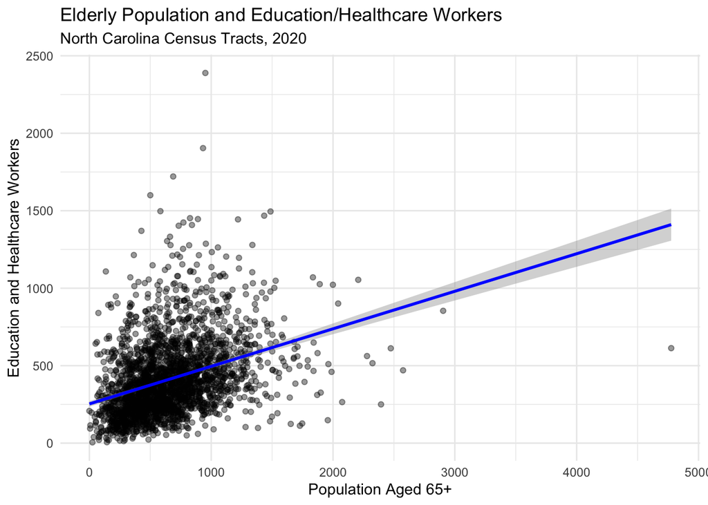

```r
ggplot(nc_tracts, aes(
  x = elderly,
  y = educational.health.care.countE
)) +
  geom_point(alpha = 0.4) +
  geom_smooth(method = "lm", color = "blue") +
  labs(
    title = "Elderly Population and Education/Healthcare Workers",
    subtitle = "North Carolina Census Tracts, 2020",
    x = "Population Aged 65+",
    y = "Education and Healthcare Workers"
  ) +
  theme_minimal()
```

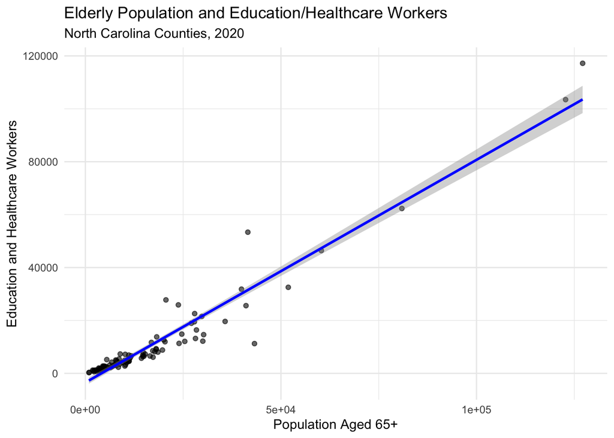

```r
ggplot(nc_county, aes(
  x = elderly,
  y = educational.health.care.countE
)) +
  geom_point(alpha = 0.6) +
  geom_smooth(method = "lm", color = "blue") +
  labs(
    title = "Elderly Population and Education/Healthcare Workers",
    subtitle = "North Carolina Counties, 2020",
    x = "Population Aged 65+",
    y = "Education and Healthcare Workers"
  ) +
  theme_minimal()
```

When comparing the two graphs, I noticed that the relationship between the elderly population and education and healthcare employment is much stronger at the county level. The county-level graph shows that most points follow the regression line fairly closely, while the census tract graph has more scattered points. This matches the adjusted R-squared values, which were 0.93 for counties and 0.1233 for census tracts. One possible reason for this difference is that counties cover larger populations, so the relationship between the two variables becomes more noticeable when the data is grouped into larger geographic areas.

### Mapping Regression Residuals

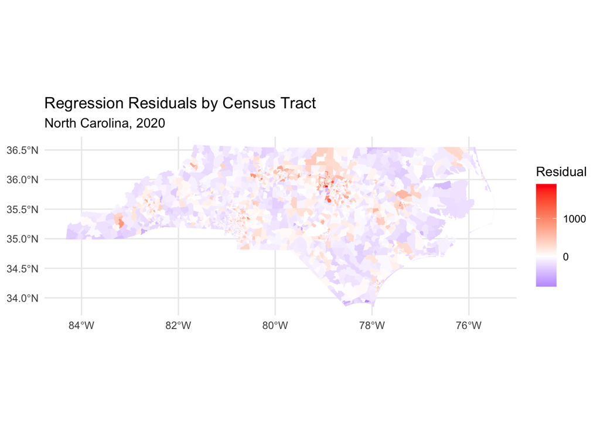

```r
nc_tracts$residuals <- NA_real_

used_rows <- as.integer(
  rownames(model.frame(first.model.tract))
)

nc_tracts$residuals[used_rows] <-
  residuals(first.model.tract)

# Map the residuals
ggplot(nc_tracts) +
  geom_sf(aes(fill = residuals), color = NA) +
  scale_fill_gradient2(
    low = "blue",
    mid = "white",
    high = "red",
    midpoint = 0,
    na.value = "grey90"
  ) +
  labs(
    title = "Regression Residuals by Census Tract",
    subtitle = "North Carolina, 2020",
    fill = "Residual"
  ) +
  theme_minimal()
```

The residual map shows how the model’s predictions differ from the actual number of education and healthcare workers across North Carolina census tracts. The red areas represent places where the model underestimated the number of workers, while the purple areas represent places where it overestimated them. I noticed that some of the larger positive residuals appear in central North Carolina, while negative residuals are spread across several parts of the state. This suggests that the relationship between elderly population and employment is not the same everywhere, and other local factors may help explain the differences.

### County level Residual Map

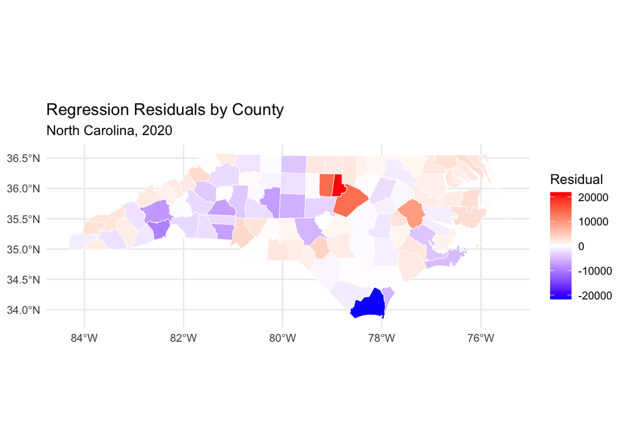

```r
nc_county$residuals <- residuals(first.model.county)

ggplot(nc_county) +
  geom_sf(aes(fill = residuals), color = "white", linewidth = 0.2) +
  scale_fill_gradient2(
    low = "blue",
    mid = "white",
    high = "red",
    midpoint = 0
  ) +
  labs(
    title = "Regression Residuals by County",
    subtitle = "North Carolina, 2020",
    fill = "Residual"
  ) +
  theme_minimal()
```

The county-level residual map shows that the model does not predict education and healthcare employment equally well across North Carolina. Some counties in the north-central part of the state have positive residuals, meaning they have more workers than the model predicted. There is also a county in southeastern North Carolina with a large negative residual, meaning the model predicted more workers than were actually reported. Although the county-level regression had a high adjusted R-squared of 0.93, these differences show that the model still makes errors in certain areas. This suggests that other factors besides the elderly population may help explain employment patterns.

## Second Model: Multiple Regressions

For my second model, I wanted to see whether adding more variables would help explain the number of education and healthcare workers in North Carolina. Along with the elderly population, I included undergraduate enrollment and median home value to see whether these factors were also associated with employment in these fields.

```r
second.model.tract <- lm(
  educational.health.care.countE ~ elderly +
    undergradE + median.home.valueE,
  data = nc_tracts
)

summary(second.model.tract)
```

```
##
## Call:
## lm(formula = educational.health.care.countE ~ elderly + undergradE +
##     median.home.valueE, data = nc_tracts)
##
## Residuals:
##      Min       1Q   Median       3Q      Max
## -1093.31  -132.59   -38.05    93.50  1839.99
##
## Coefficients:
##                     Estimate Std. Error t value Pr(>|t|)
## (Intercept)        1.572e+02  1.147e+01  13.714  < 2e-16 ***
## elderly            2.435e-01  1.195e-02  20.386  < 2e-16 ***
## undergradE         2.042e-01  1.180e-02  17.304  < 2e-16 ***
## median.home.valueE 2.656e-04  3.518e-05   7.552 5.93e-14 ***
## ---
## Signif. codes:  0 '***' 0.001 '**' 0.01 '*' 0.05 '.' 0.1 ' ' 1
##
## Residual standard error: 214 on 2555 degrees of freedom
## Multiple R-squared:  0.2324, Adjusted R-squared:  0.2315
## F-statistic: 257.9 on 3 and 2555 DF,  p-value: < 2.2e-16
```

For my second regression model, I included elderly population, undergraduate enrollment, and median home value to see whether these variables were related to education and healthcare employment. All three variables had positive coefficients and p-values below 0.05, meaning they were statistically significant. The elderly population had a coefficient of 0.2435, while undergraduate enrollment had a coefficient of 0.2042. Median home value also had a positive coefficient, although its effect per dollar was much smaller. The adjusted R-squared was 0.2315, meaning the model explained about 23.15% of the variation in employment. This was an improvement from the first model, which only explained 12.33%.

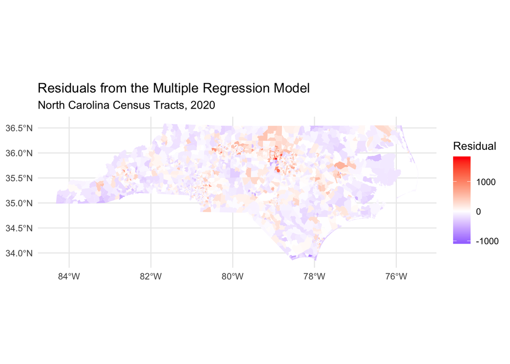

```r
nc_tracts$second_residuals <- NA_real_

used_rows <- as.integer(
  rownames(model.frame(second.model.tract))
)

nc_tracts$second_residuals[used_rows] <-
  residuals(second.model.tract)

# Create residual map
ggplot(nc_tracts) +
  geom_sf(aes(fill = second_residuals), color = NA) +
  scale_fill_gradient2(
    low = "blue",
    mid = "white",
    high = "red",
    midpoint = 0,
    na.value = "grey90"
  ) +
  labs(
    title = "Residuals from the Multiple Regression Model",
    subtitle = "North Carolina Census Tracts, 2020",
    fill = "Residual"
  ) +
  theme_minimal()
```

The residual map for my second model shows that there are still differences between the predicted and actual number of education and healthcare workers across North Carolina. Some areas have positive residuals, while others have negative residuals, meaning the model underestimates employment in some places and overestimates it in others. Compared to the first model, the second model explains more variation because it includes additional variables like undergraduate enrollment and median home value. However, the residuals show that there are still other factors affecting employment that the model does not account for.

# Results

Overall, my results show that elderly population has a positive relationship with education and healthcare employment in North Carolina. The first regression model had an adjusted R-squared of 0.1233 at the census tract level, compared to 0.93 at the county level. This suggests that the relationship is much stronger when looking at larger geographic areas. My second model included undergraduate enrollment and median home value, which increased the adjusted R-squared to 0.2315 at the census tract level. All three variables were statistically significant, but the residual maps showed that the models still had prediction errors in different parts of the state.

# Conclusion

This analysis helped me understand how linear regression can be used to examine relationships between demographic characteristics and employment. I found that elderly population was positively associated with education and healthcare employment, especially at the county level. Adding undergraduate enrollment and median home value improved the census tract model, but it still did not explain all of the variation. One limitation is that counties with larger populations naturally tend to have more elderly residents and workers, which may affect the results. Overall, this assignment showed me that both the variables included in a model and the geographic scale of the analysis can influence the results.

# Reflection Questions

## How long did the assignment take you to complete?

Around 2-3 hours

## Where did you get stuck? Where did you go for help?

I initially got stuck when trying to download the Census data because RStudio could not find a function, and I realized that I needed to load the tidycensus package before running the code.

## Did you find any errors in the assignment?

I realized that some of the instructions referenced Assignment 7 even though this was Assignment 8.